# Lessons learned from my man Andrew Ng

## *A simple neural net in Python with Numpy*

[figure not shown]

# Lessons learned from my man Andrew Ng

## *A simple neural net in Python with Numpy*

[figure not shown]

# 3 learning goals

- How does back propagation **actually** work?
- How can a neural net approximate complex features?
- How is each node in the neural net learning something different, and not just the same "feature"?

## bonus goals

- More proficient with Numpy
- Make a jupyter notebook presentation :)

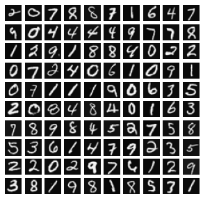

```python
# https://towardsdatascience.com/andrew-ngs-machine-learning-course-in-python-neural-networks-e526b41fdcd9
import matplotlib.pyplot as plt

def plot_100_digits():
    fig, axis = plt.subplots(10,10,figsize=(5,5))
    for i in range(10):
        for j in range(10):
            axis[i,j].imshow(X[np.random.randint(0,5001),:].reshape(20,20,order="F"), cmap="gray") #reshape back to 20 pixel by 20 pixel
            axis[i,j].axis("off")

plot_100_digits()
```

[figure not shown]

```python
def sigmoid(z):
    return 1/(1+np.exp(-z))
```

# Minimize the loss

#### Loss function for multi-class classification problem

[figure not shown]

```python
def loss(X, y_one_hot, Thetas, llambda):
    y = y_one_hot
    total_loss = 0
    for i in range(len(y[0])):
        total_loss = total_loss + (-y[:, i].dot(np.log(predict_vector(X, Thetas)[:, i]))-(1-y[:, i]).dot(np.log(1-predict_vector(X, Thetas)[:, i])))/len(X)
    for i in range(len(Thetas)):
        relevant_thetas = Thetas[i][:, 1:].flatten()
        total_loss = total_loss + llambda/2/len(X)*relevant_thetas.dot(relevant_thetas)
    return total_loss
```

# 1. How does back propagation actually work?

Okay, so I found out back propagation is actually just 1 step in the algorithm.

Actually my question is, how does a neural net train it's weights exactly?

Turns out that's actually not that hard to understand!

## Step 1: initialize weights and weight-updates (= gradients)

```python
def initialize_weights(input_size, hidden_layer_size, output_size):
    Thetas = []
    Thetas.append(np.random.uniform(-0.12, 0.12, [hidden_layer_size, input_size + 1]))
    Thetas.append(np.random.uniform(-0.12, 0.12, [output_size, hidden_layer_size + 1]))
    return Thetas

def initialize_gradients(input_size, hidden_layer_size, output_size):
    Gradients = []
    Gradients.append(np.zeros([hidden_layer_size, input_size + 1]))
    Gradients.append(np.zeros([output_size, hidden_layer_size + 1]))
    return Gradients
```

## Step 2: for each x in pseudo code

- compute the activation value of each node by a feed forward through the net
- determine how much each node contributed to the loss of the prediction (=deltas). This is actually the back propagation step!
- determine how much the weights should be updated to get a smaller loss

## Step 2: for each x in actual code

```python
def get_activations_by_single_feed_forward(x, Thetas):
    activations = []
    activations.append(np.concatenate(([1],x))) # add intercept
    for i in range(len(Thetas)):
        next_activations = sigmoid(activations[i].dot(np.transpose(Thetas[i])))
        if i == len(Thetas) - 1:
            activations.append(next_activations)
        else:
            activations.append(np.concatenate(([1],next_activations))) # add intercept
    return activations

def get_deltas_by_back_prop(y, activations, Thetas):
    deltas = []
    deltas.append(activations[-1] - y)
    for i in reversed(range(1, len(Thetas))):
        previous_deltas = np.transpose(Thetas[i]).dot(deltas[0])*activations[i]*(1-activations[i])
        deltas.insert(0, previous_deltas)
    return deltas

def accumulate_Gradients(Gradients, activations, deltas):
    for i in range(len(Gradients)):
        if i == len(Gradients) - 1:
            Gradients[i] = Gradients[i] + np.outer(deltas[i], activations[i])
        else:
            Gradients[i] = Gradients[i] + np.outer(deltas[i][1:], activations[i])
    return Gradients
```

## Step 3: update the weights!

```python
def regularlize_Gradients(Gradients, llambda, Thetas, X):
    for i in range(len(Gradients)):
        Gradients[i] = Gradients[i] / len(X) + np.c_[ np.zeros(Thetas[i].shape[0]), Thetas[i][:, 1:] ] * llambda / len(X)
    return Gradients

def gradient_descent(Thetas, Gradients, alfa):
    for i in range(len(Thetas)):
        Thetas[i] = Thetas[i] - alfa * Gradients[i]
    return Thetas
```

# Time to train our model!

```python
iterations = 1000
alfa = 1
llambda = 1
losses = np.zeros(iterations)
Thetas = initialize_weights(400, 25, 10)
y_hot = one_hot_encode(y)

for iteration in range(iterations):
    print(iteration)

    Gradients = initialize_gradients(400, 25, 10)
    for i in range(len(X)):
        activations = get_activations_by_single_feed_forward(X[i], Thetas)
        deltas = get_deltas_by_back_prop(y_hot[i], activations, Thetas)
        Gradients = accumulate_Gradients(Gradients, activations, deltas)

    Gradients = regularlize_Gradients(Gradients, llambda, Thetas, X)
    Thetas = gradient_descent(Thetas, Gradients, alfa)

    losses[iteration] = loss(X, y_hot, Thetas, llambda)
    print(losses[iteration])
```

```
0
3.501232811894786
1
3.258001804108702
2
3.245544748403117
3
3.2374210255302422
4
3.22978284463599
5
3.2219034682057424
6
3.2135002691443613
7
3.204404251999387
8
3.1944777637708652
9
3.18359081580365
10
3.1716150222515145
11
3.1584232283819063
12
3.1438913123370615
13
3.1279011336375775
14
3.1103442933907632
15
3.0911265050837553
16
3.0701723286904095
17
3.047429917333828
18
3.0228753242554514
19
2.9965158666555114
```

[output cut: 1945 more lines]

```
0.45946808213279117
993
0.45934478242625254
994
0.4592216618088736
995
0.4590987198670021
996
0.4589759561891471
997
0.4588533703659644
998
0.4587309619902437
999
0.4586087306568945
```

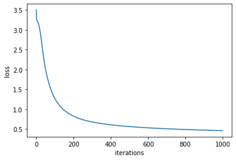

```python
import matplotlib.pyplot as plt

plt.plot(losses)
plt.ylabel('loss')
plt.xlabel('iterations')
plt.show()
```

```
accuracy:   [0.956]
all indices where model makes a mistake:
[112 131 133 142 261]
9
```

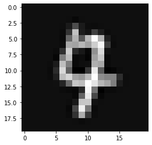

```python
y_predicted = predict_value(X, Thetas)

print_accuracy(y, y_predicted)

print('all indices where model makes a mistake:')
print(np.argwhere((y_predicted - y.flatten()) != 0).flatten()[:5])

print(y_predicted[2201])
plot_digit(2201)
```

# 2. How can a neural net approximate complex features?

- Neural nets can approximate any function
- We don't need to feature engineering - the net will do that for us
- So how can it find relevant features with only linear combinations and activations?

More explicitly how can it approximate

- logical operators,
- polynomial terms (e.g. $x_1^ 2$ or $x_1 * x_2$)

# Logical operators

[figure not shown]

# Polynomial terms (e.g. $x_1^ 2$ or $x_1 * x_2$)

[This blogpost](https://medium.com/datadriveninvestor/when-to-multiply-inside-your-neural-network-ee39863da446) explains that:

- applying log() turns multiplications into additions, job done! This is also useful to limit the range of input values.
- secondly, neural networks can approximate arbitrary functions. And of course, it can approximate a multiplier as wells
- however, the model just learns to approximate the output for the examples in the training data, it understands nothing about multiplication. In other words, what the model has learnt doesn’t generalize to true multiplication.
- so if you have a strong intuition that multiplication is the right way to model certain relations, then it may be better to explicitly enforce that in the network.

# 3. How is each node in the neural net learning something different, and not just the same "feature"?

Why isn't each node in a hidden layer converging to the same `feature`?

Part of the answer: non-zero initialization

[figure not shown]

```python
def initialize_weights(input_size, hidden_layer_size, output_size):
    Thetas = []
    Thetas.append(np.random.uniform(-0.12, 0.12, [hidden_layer_size, input_size + 1]))
    Thetas.append(np.random.uniform(-0.12, 0.12, [output_size, hidden_layer_size + 1]))
    return Thetas
```

# Is that enough?

More people are wondering on [stackoverflow](https://stats.stackexchange.com/questions/413712/neural-network-why-can-nns-have-identical-structure-in-the-hidden-units-and-sti)...

[figure not shown]

# The other part of the answer

[figure not shown]

# The other part of the answer

[figure not shown]

# The end

Check it out on [MissEnergy's Github](https://github.com/missEnergy/ml_course)

[figure not shown]